# Tables using Children and Table Functions

EE Holmes

## Overview

This is an example of a Tables Rmd with separate Rmds for the individual tables. The table code is in the `tables` folder. `Table1` is a simple table. `Table_Counts` is a table function that is then called to make tables with the same format but different input data. For this example, I am only going to use `kable()` for all output types. See `Tables.Rmd` and `Table_Counts_flex.Rmd` for examples of using the **kableExtra**, **xtable** and **flextable** packages.

## Tips

### General set-up

- Be a modular and simple as you can. You can spend many hours figuring out how to do things in R Markdown (that are simple in Word).
- Don’t make everyone in your team be the R Markdown wizard. You only need one person to build the framework.
- Use simple child Rmds so that other team members work only on simple Rmd flat files.
- Don’t put all your tables or figures in one huge file: `Table xyz.Rmd`, `Table abc.Rmd`. Have your dedicated R Markdown wizard figure out the automatic numbering.
- Copy reports built by others who doing something similar to you. TALK within your center or across centers and share work.

### Specific tips

- best not to use chunk labels in the your Rmd children. It’s too easy to get duplicate labels accidentally.
- if you need to reference a file in a folder, let R create the path so that it is compatible across systems:

```
file.path('images', 'figure1.Rmd')
```

- I always use the **here** package so that my code doesn’t break if I happen to issue a change workspace directory command.

```
file.path(here::here(), 'images', 'figure1.Rmd')
```

- Making tables within `for` looks is tricky and it is different if you are outputting to Word versus html and also depends on what package that you use. See my Rmd files for examples of how to set it up, but also be prepared for things breaking in the future as package writers change things. This feature is really fluid. Web searches on stackoverflow are key for solving these problems.

### Working with Word

For many of us, Word is part of our team’s workflow. Word is binary so working in that destroys the history that you are capturing with Git. Word is also not compatible with automization, so is inefficient. That said, it is often part of our workflow and the track changes feature is often needed. Rather than trying to fight that I suggest the following:

- Don’t build the whole report in Word. Work on individual text sections and then have R Studio (via pandoc/knitr) assemble the report (text, figures, tables) from the individual parts.
- How to deal with the team needing to review the assembled document (text, figures, tables):
  - Try to modularize. So maybe make individual chapters and have review happen at that level. Then you incorporate the changes into the plain text manually.
  - Use templates to make your Word doc look the way you want. The default is kind of weird. See my example and read about using Word templates with R Markdown [here](https://bookdown.org/yihui/rmarkdown-cookbook/word-template.html).

#### Making tables look nice in Word

The example in `Table_Counts.Rmd` and `Table_Counts_flex.Rmd` shows you tricks to make nice Word tables.

- how to include a page break in your Word doc between tables.
- using `format="pandoc"` for the table
- using `results='asis' and`print()` so you can use for loops.
- centering your tables is next to impossible with `kable()`. Use **flextable** if you need that.

# A Sample title

## Eli E. Holmes$^1$, Sarah Jean$^1$

1. Northwest Fisheries Science Center, NOAA, Seattle, WA.

# Acknowledgements

Phasellus non diam posuere, laoreet velit sed, egestas felis. Etiam eget neque in tellus lacinia tincidunt. Pellentesque scelerisque odio velit, nec fringilla nibh iaculis non. Aenean sit amet nulla ipsum. Cras felis lacus, pulvinar ac nisi et, convallis pulvinar turpis. Morbi non nibh lacus. Morbi vitae lorem massa. Sed ut turpis vel felis posuere commodo lacinia ac mi. Donec finibus lectus sit amet elit finibus, vitae rhoncus ligula tincidunt. Phasellus vitae blandit lacus. Integer sed nisl fermentum, pulvinar mauris in, posuere enim. Proin sit amet semper urna. Vivamus aliquet rutrum diam ac luctus.

# Abstract

Phasellus non diam posuere, laoreet velit sed, egestas felis. Etiam eget neque in tellus lacinia tincidunt. Pellentesque scelerisque odio velit, nec fringilla nibh iaculis non. Aenean sit amet nulla ipsum. Cras felis lacus, pulvinar ac nisi et, convallis pulvinar turpis. Morbi non nibh lacus. Morbi vitae lorem massa. Sed ut turpis vel felis posuere commodo lacinia ac mi. Donec finibus lectus sit amet elit finibus, vitae rhoncus ligula tincidunt. Phasellus vitae blandit lacus. Integer sed nisl fermentum, pulvinar mauris in, posuere enim. Proin sit amet semper urna. Vivamus aliquet rutrum diam ac luctus.

# Introduction

Lorem ipsum dolor sit amet, (Smith and Weston 1954; Green, Fred, and Norbert 1900) consectetur adipiscing elit. Nam commodo sit amet nibh non molestie. Maecenas hendrerit nisl velit, a condimentum enim lobortis sit amet. Ut vitae nunc sed mauris condimentum fermentum. Mauris pellentesque nec neque id elementum. Suspendisse a quam aliquam, facilisis urna venenatis, malesuada diam. Pellentesque in fringilla orci. Cras sed purus urna. Ut pharetra enim ut ligula egestas mattis.

Phasellus non diam posuere, laoreet velit sed, egestas felis. Etiam eget neque in tellus lacinia tincidunt. Pellentesque scelerisque odio velit, nec fringilla nibh iaculis non. Aenean sit amet nulla ipsum. Cras felis lacus, pulvinar ac nisi et, convallis pulvinar turpis. Morbi non nibh lacus. Morbi vitae lorem massa. Sed ut turpis vel felis posuere commodo lacinia ac mi. Donec finibus lectus sit amet elit finibus, vitae rhoncus ligula tincidunt. Phasellus vitae blandit lacus. Integer sed nisl fermentum, pulvinar mauris in, posuere enim. Proin sit amet semper urna. Vivamus aliquet rutrum diam ac luctus.

Quisque in nibh sit amet nunc mollis porttitor quis et mauris. Sed non condimentum leo, ac condimentum est. Duis ac venenatis nulla, et aliquet elit. Suspendisse potenti. Duis mollis dui at semper luctus. Maecenas euismod finibus condimentum. Fusce vitae gravida massa. Mauris metus est, pretium non semper vel, dictum vel augue.

Curabitur tempus, leo quis volutpat rhoncus, turpis elit vehicula dolor, id tincidunt augue nunc at enim. In vel enim mattis, varius orci at, tempus ante. Morbi massa elit, pharetra ac libero at, porta tempus quam. Ut fringilla, tortor ac tristique euismod, magna felis vestibulum turpis, quis congue mauris leo nec felis. Aliquam viverra et nibh ut blandit. Praesent sed luctus odio. Pellentesque finibus velit dolor. Morbi ac pulvinar ex, id dapibus eros. Cras interdum arcu viverra auctor tristique. Suspendisse venenatis volutpat ultricies.

Donec bibendum pharetra arcu vitae porttitor. Morbi ac quam nunc. Ut cursus dolor a mauris aliquet vulputate. Morbi elementum ullamcorper augue, et tincidunt libero facilisis posuere. Nam congue velit non elit sollicitudin aliquet. Donec lobortis nunc ligula, id sollicitudin erat rhoncus cursus. Ut egestas orci libero, eu malesuada ex sollicitudin sed. Sed ornare nunc eget massa scelerisque, nec egestas nulla commodo. Pellentesque efficitur accumsan ullamcorper. Nulla facilisi. Maecenas tristique luctus malesuada. Phasellus id enim maximus, tempus tellus eu, dignissim sapien. Integer et mauris in lectus condimentum pellentesque non a felis.

|  | Df | Deviance | Resid. Df | Resid. Dev |
| --- | --- | --- | --- | --- |
| NULL |  |  | 99 | 129.5 |
| ethnicty | 3 | 47.2 | 96 | 82.2 |
| grade | 1 | 1.7 | 95 | 80.5 |
| ethnicty:grade | 3 | 7.2 | 92 | 73.3 |

Quisque in nibh sit amet nunc mollis porttitor quis et mauris. Sed non condimentum leo, ac condimentum est. Duis ac venenatis nulla, et aliquet elit. Suspendisse potenti. Duis mollis dui at semper luctus. Maecenas euismod finibus condimentum. Fusce vitae gravida massa. Mauris metus est, pretium non semper vel, dictum vel augue.

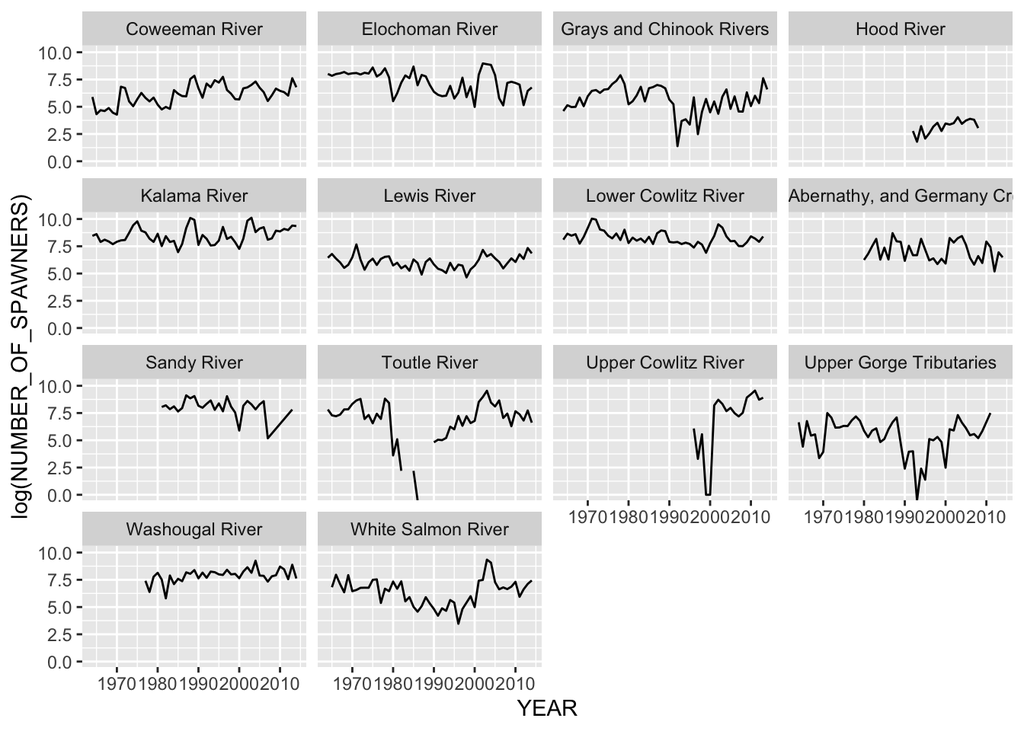

Figure 1. Plot of the data

The **flextable** package will do a bit nicer tables than **kable**.

| Table 2. Coweeman River. Yearly counts of Spawners and Fracwild for 2000 to 2014 Year | Table 2. Coweeman River. Yearly counts of Spawners and Fracwild for 2000 to 2014 Spawners | Table 2. Coweeman River. Yearly counts of Spawners and Fracwild for 2000 to 2014 Fracwild |
| --- | --- | --- |
| 2000 | 290 | 1.00 |
| 2001 | 802 | 0.73 |
| 2002 | 877 | 0.97 |
| 2003 | 1,106 | 0.89 |
| 2004 | 1,503 | 0.91 |
| 2005 | 853 | 0.60 |
| 2006 | 566 | 1.00 |
| 2007 | 251 | 1.00 |
| 2008 | 424 | 0.52 |
| 2009 | 783 | 0.63 |
| 2010 | 639 | 0.70 |
| 2011 | 566 | 0.88 |
| 2012 | 413 | 0.86 |
| 2013 | 2,035 | 0.69 |
| 2014 | 890 | 0.96 |

** data file date: Tue Jun 15 13:24:51 2021 -0700  
* These spawner counts are from river redd surveys.

| Table 3. Elochoman River. Yearly counts of Spawners and Fracwild for 2000 to 2014 Year | Table 3. Elochoman River. Yearly counts of Spawners and Fracwild for 2000 to 2014 Spawners | Table 3. Elochoman River. Yearly counts of Spawners and Fracwild for 2000 to 2014 Fracwild |
| --- | --- | --- |
| 2000 | 146 | 0.62 |
| 2001 | 2,806 | 0.82 |
| 2002 | 7,893 | 0.00 |
| 2003 | 7,348 | 0.65 |
| 2004 | 6,880 | 0.01 |
| 2005 | 2,699 | 0.05 |
| 2006 | 324 | 1.00 |
| 2007 | 168 | 1.00 |
| 2008 | 1,320 | 0.10 |
| 2009 | 1,467 | 0.18 |
| 2010 | 1,318 | 0.12 |
| 2011 | 1,127 | 0.05 |
| 2012 | 172 | 0.26 |
| 2013 | 637 | 0.29 |
| 2014 | 869 | 0.22 |

** data file date: Tue Jun 15 13:24:51 2021 -0700  
* These spawner counts are from river redd surveys.

# References

Green, R. J., U. P. Fred, and W. P. Norbert. 1900. “Things That Go Bump in the Night.” *Psych. Today* 46: 345–678.

Smith, J. G., and H. K. Weston. 1954. “Nothing Particular in This Year’s History.” *J. Geophys. Res.* 2: 14–15.